# Social Change in Anticipated Caring Roles:

A Portrait of Young Americans’ Views of Themselves in Adult Caring Relationships

Joanna R. Pepin

*University of Toronto*

Melissa A. Milkie

*University of Toronto*

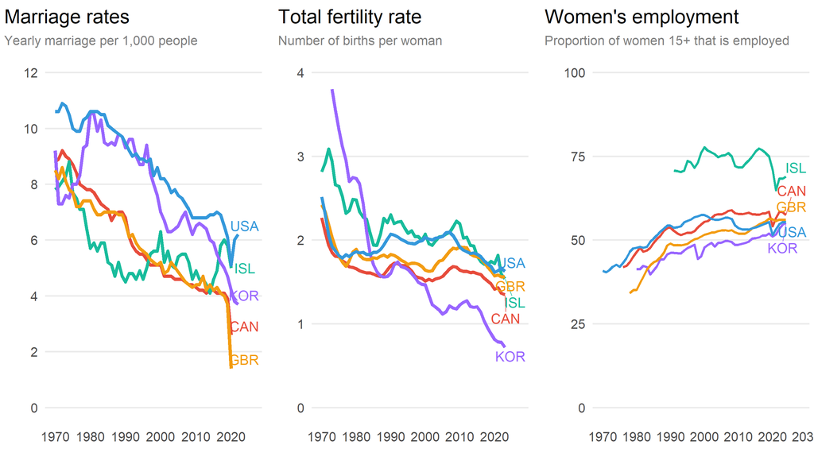

ourworldindata.org/grapher/marriage-rate-per-1000-inhabitants  
ourworldindata.org/grapher/children-born-per-woman  
ourworldindata.org/grapher/female-employment-to-population-ratio

## Caregiving Ambitions Framework

**Motivation to give care**, across a variety of contexts and over the lifespan, **is central to understanding life goals** and ultimately behavior.

Bear 2019

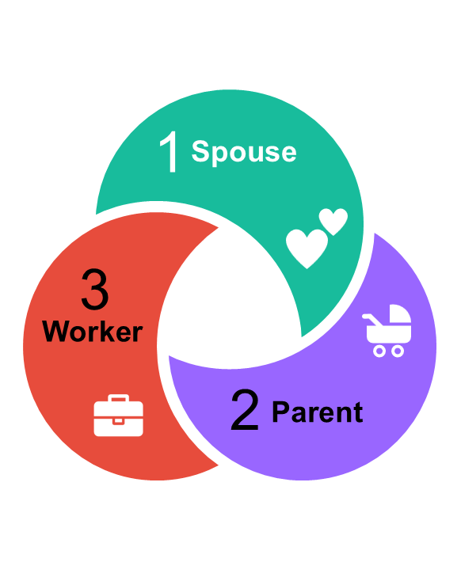

## Research Questions

1. Have youths’ expectations of becoming a good spouse or parent (*direct caregiving*) and a good worker (*indirect caregiving*) changed across historical time?
2. Do expectations of being a good caregiver change through early adulthood (ages 18–30)?
3. Do early expectations (*RQ1*) or the trajectories (*RQ2*) about becoming a good spouse or parent predict transitions into these roles?

## Monitoring the Future Surveys

Nationally representative sample of U.S. 12th-graders (1976-2024)

N = 100,251

**How good do you think you would be as a**:

- husband or wife?
- parent?
- worker on a job?

**poor | not so good | fairly good | good | very good**

https://www.icpsr.umich.edu/web/ICPSR/series/35

## Sample

| **Variable** | **Overall** N = 100,251 (100%) | **Men** N = 47,804 (48%) | **Women** N = 52,447 (52%) |
| --- | --- | --- | --- |
| Mom completed college | 33% | 34% | 32% |
| Race identity |  |  |  |
| White | 71% | 73% | 70% |
| Black | 11% | 9.5% | 12% |
| Another race | 18% | 18% | 18% |
| Region |  |  |  |
| Northeast | 19% | 19% | 20% |
| Midwest | 27% | 27% | 27% |
| South | 34% | 34% | 34% |
| West | 19% | 19% | 19% |

Source: Monitoring the Future (MTF) Surveys (1976-2024)

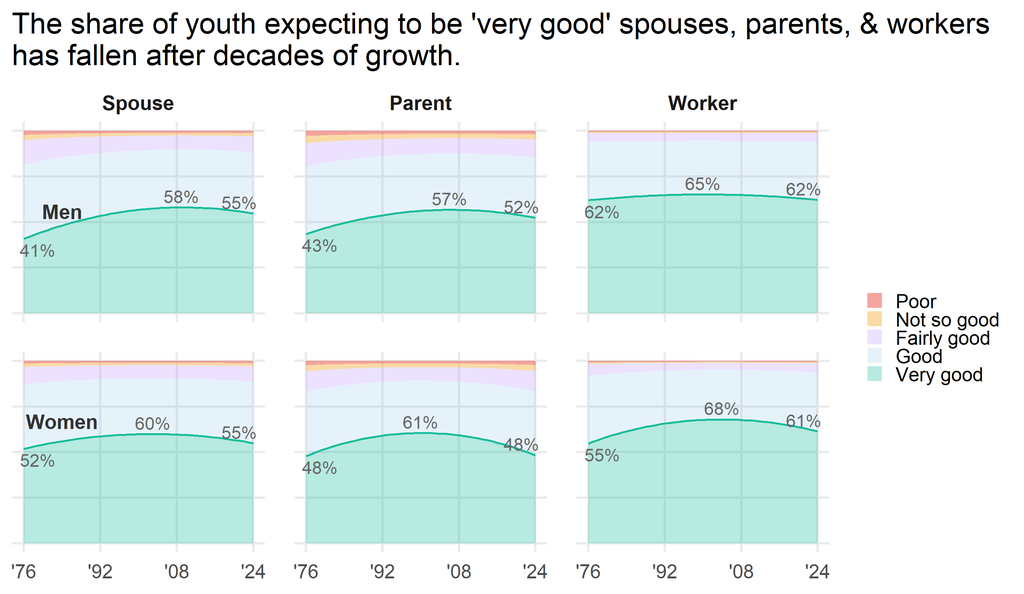

Predicted probability of expectations of future adult roles, adjusted for mother’s education, race, and region;  
Data: *Monitoring the Future Surveys (U.S. 12th grade students)*

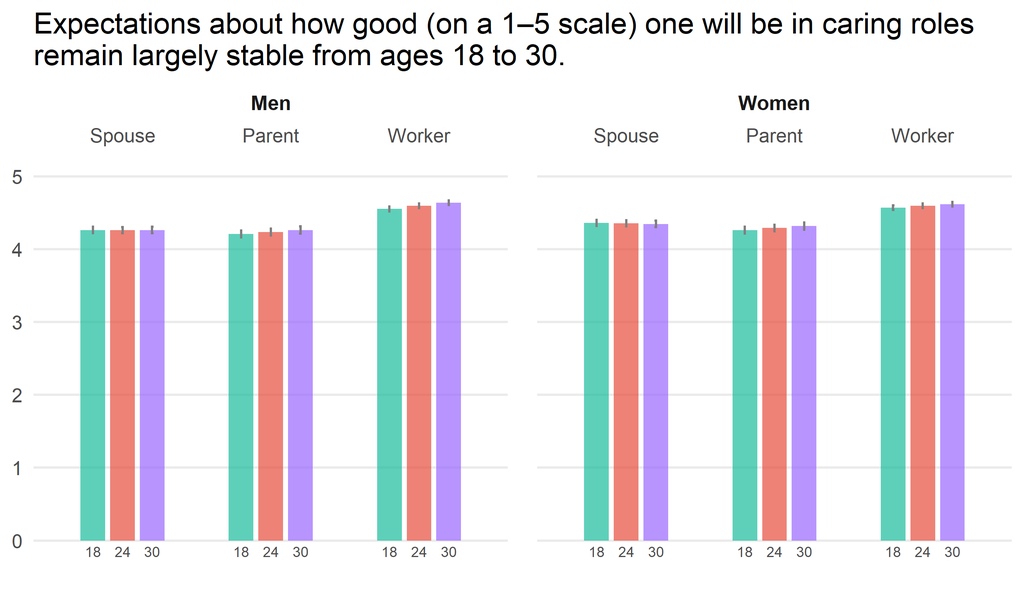

Predicted expectations (1–5 scale: ‘poor’ to ‘very good’) from MLMC regressions for ages 18–30, adjusted for birth decade, race, mother’s education and employment, and family structure;  
Data: *Monitoring the Future Surveys (U.S. 12th grade students)*

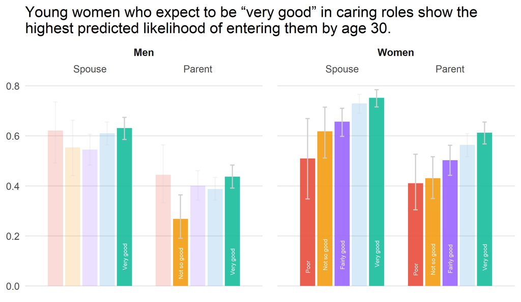

Predicted probability of marriage or parenthood by age 30, adjusted for birth decade, race, maternal education and employment, and family structure;  
Data: *Monitoring the Future Surveys (U.S. 12th grade students)*;  
Note: Highlighted bars denote statistically significant difference from ‘very good’, within role and gender;

## Summary

- **Historical shifts in caregiving expectations (RQ1)**  
  A decline in recent decade in how strongly young people anticipate excelling in caring roles.
- **Developmental stability in early adulthood (RQ2)**  
  Young adults’ views of their caring ability stay largely stable through early adulthood.
- **Predictive power of early expectations (RQ3)**  
  High early caregiving expectations shape later life direct caring transitions…for women.

# Thank you!

Joanna R. Pepin  
*University of Toronto*

Melissa A. Milkie  
*University of Toronto*

[figure not shown]